# Risk Factor Analysis

## Outcome Variable

**Outcome Variable:** ever_stunted

## Predictor Variables

**Intervention Variable:** feducyrs

**Adjustment Set:**

unadjusted

## Stratifying Variables

The analysis was stratified on these variable(s):

- agecat
- studyid
- country

## Data Summary

| agecat | studyid | country | feducyrs | ever_stunted | n_cell | n | outcome_variable |
| --- | --- | --- | --- | --- | --- | --- | --- |
| 0-24 months | ki0047075b-MAL-ED | BANGLADESH | High | 0 | 31 | 149 | ever_stunted |
| 0-24 months | ki0047075b-MAL-ED | BANGLADESH | High | 1 | 23 | 149 | ever_stunted |
| 0-24 months | ki0047075b-MAL-ED | BANGLADESH | Low | 0 | 15 | 149 | ever_stunted |
| 0-24 months | ki0047075b-MAL-ED | BANGLADESH | Low | 1 | 25 | 149 | ever_stunted |
| 0-24 months | ki0047075b-MAL-ED | BANGLADESH | Medium | 0 | 19 | 149 | ever_stunted |
| 0-24 months | ki0047075b-MAL-ED | BANGLADESH | Medium | 1 | 36 | 149 | ever_stunted |
| 0-24 months | ki0047075b-MAL-ED | INDIA | High | 0 | 17 | 147 | ever_stunted |
| 0-24 months | ki0047075b-MAL-ED | INDIA | High | 1 | 27 | 147 | ever_stunted |
| 0-24 months | ki0047075b-MAL-ED | INDIA | Low | 0 | 28 | 147 | ever_stunted |
| 0-24 months | ki0047075b-MAL-ED | INDIA | Low | 1 | 31 | 147 | ever_stunted |
| 0-24 months | ki0047075b-MAL-ED | INDIA | Medium | 0 | 18 | 147 | ever_stunted |
| 0-24 months | ki0047075b-MAL-ED | INDIA | Medium | 1 | 26 | 147 | ever_stunted |
| 0-24 months | ki0047075b-MAL-ED | NEPAL | High | 0 | 32 | 98 | ever_stunted |
| 0-24 months | ki0047075b-MAL-ED | NEPAL | High | 1 | 10 | 98 | ever_stunted |
| 0-24 months | ki0047075b-MAL-ED | NEPAL | Low | 0 | 16 | 98 | ever_stunted |
| 0-24 months | ki0047075b-MAL-ED | NEPAL | Low | 1 | 12 | 98 | ever_stunted |
| 0-24 months | ki0047075b-MAL-ED | NEPAL | Medium | 0 | 15 | 98 | ever_stunted |
| 0-24 months | ki0047075b-MAL-ED | NEPAL | Medium | 1 | 13 | 98 | ever_stunted |
| 0-24 months | ki0047075b-MAL-ED | PERU | High | 0 | 45 | 250 | ever_stunted |
| 0-24 months | ki0047075b-MAL-ED | PERU | High | 1 | 75 | 250 | ever_stunted |
| 0-24 months | ki0047075b-MAL-ED | PERU | Low | 0 | 28 | 250 | ever_stunted |
| 0-24 months | ki0047075b-MAL-ED | PERU | Low | 1 | 41 | 250 | ever_stunted |
| 0-24 months | ki0047075b-MAL-ED | PERU | Medium | 0 | 20 | 250 | ever_stunted |
| 0-24 months | ki0047075b-MAL-ED | PERU | Medium | 1 | 41 | 250 | ever_stunted |
| 0-24 months | ki0047075b-MAL-ED | SOUTH AFRICA | High | 0 | 14 | 110 | ever_stunted |
| 0-24 months | ki0047075b-MAL-ED | SOUTH AFRICA | High | 1 | 29 | 110 | ever_stunted |
| 0-24 months | ki0047075b-MAL-ED | SOUTH AFRICA | Low | 0 | 18 | 110 | ever_stunted |
| 0-24 months | ki0047075b-MAL-ED | SOUTH AFRICA | Low | 1 | 19 | 110 | ever_stunted |
| 0-24 months | ki0047075b-MAL-ED | SOUTH AFRICA | Medium | 0 | 10 | 110 | ever_stunted |
| 0-24 months | ki0047075b-MAL-ED | SOUTH AFRICA | Medium | 1 | 20 | 110 | ever_stunted |

[output cut: 330 more lines]

The following strata were considered:

- agecat: 0-24 months, studyid: ki0047075b-MAL-ED, country: BANGLADESH
- agecat: 0-24 months, studyid: ki0047075b-MAL-ED, country: INDIA
- agecat: 0-24 months, studyid: ki0047075b-MAL-ED, country: NEPAL
- agecat: 0-24 months, studyid: ki0047075b-MAL-ED, country: PERU
- agecat: 0-24 months, studyid: ki0047075b-MAL-ED, country: SOUTH AFRICA
- agecat: 0-24 months, studyid: ki0047075b-MAL-ED, country: TANZANIA, UNITED REPUBLIC OF
- agecat: 0-24 months, studyid: ki1000304b-SAS-CompFeed, country: INDIA
- agecat: 0-24 months, studyid: ki1000304b-SAS-FoodSuppl, country: INDIA
- agecat: 0-24 months, studyid: ki1017093b-PROVIDE, country: BANGLADESH
- agecat: 0-24 months, studyid: ki1017093c-NIH-Crypto, country: BANGLADESH
- agecat: 0-24 months, studyid: ki1066203-TanzaniaChild2, country: TANZANIA, UNITED REPUBLIC OF
- agecat: 0-24 months, studyid: ki1113344-GMS-Nepal, country: NEPAL
- agecat: 0-24 months, studyid: ki1119695-PROBIT, country: BELARUS
- agecat: 0-24 months, studyid: ki1126311-ZVITAMBO, country: ZIMBABWE
- agecat: 0-24 months, studyid: ki1135781-COHORTS, country: GUATEMALA
- agecat: 0-24 months, studyid: ki1135781-COHORTS, country: INDIA
- agecat: 0-24 months, studyid: ki1135781-COHORTS, country: PHILIPPINES
- agecat: 0-24 months, studyid: ki1148112-LCNI-5, country: MALAWI
- agecat: 0-24 months, studyid: kiGH5241-JiVitA-3, country: BANGLADESH
- agecat: 0-24 months, studyid: kiGH5241-JiVitA-4, country: BANGLADESH
- agecat: 0-6 months, studyid: ki0047075b-MAL-ED, country: BANGLADESH
- agecat: 0-6 months, studyid: ki0047075b-MAL-ED, country: INDIA
- agecat: 0-6 months, studyid: ki0047075b-MAL-ED, country: NEPAL
- agecat: 0-6 months, studyid: ki0047075b-MAL-ED, country: PERU
- agecat: 0-6 months, studyid: ki0047075b-MAL-ED, country: SOUTH AFRICA
- agecat: 0-6 months, studyid: ki0047075b-MAL-ED, country: TANZANIA, UNITED REPUBLIC OF
- agecat: 0-6 months, studyid: ki1000304b-SAS-CompFeed, country: INDIA
- agecat: 0-6 months, studyid: ki1000304b-SAS-FoodSuppl, country: INDIA
- agecat: 0-6 months, studyid: ki1017093b-PROVIDE, country: BANGLADESH
- agecat: 0-6 months, studyid: ki1017093c-NIH-Crypto, country: BANGLADESH
- agecat: 0-6 months, studyid: ki1066203-TanzaniaChild2, country: TANZANIA, UNITED REPUBLIC OF
- agecat: 0-6 months, studyid: ki1113344-GMS-Nepal, country: NEPAL
- agecat: 0-6 months, studyid: ki1119695-PROBIT, country: BELARUS
- agecat: 0-6 months, studyid: ki1126311-ZVITAMBO, country: ZIMBABWE
- agecat: 0-6 months, studyid: ki1135781-COHORTS, country: GUATEMALA
- agecat: 0-6 months, studyid: ki1135781-COHORTS, country: INDIA
- agecat: 0-6 months, studyid: ki1135781-COHORTS, country: PHILIPPINES
- agecat: 0-6 months, studyid: ki1148112-LCNI-5, country: MALAWI
- agecat: 0-6 months, studyid: kiGH5241-JiVitA-3, country: BANGLADESH
- agecat: 0-6 months, studyid: kiGH5241-JiVitA-4, country: BANGLADESH
- agecat: 6-24 months, studyid: ki0047075b-MAL-ED, country: BANGLADESH
- agecat: 6-24 months, studyid: ki0047075b-MAL-ED, country: INDIA
- agecat: 6-24 months, studyid: ki0047075b-MAL-ED, country: NEPAL
- agecat: 6-24 months, studyid: ki0047075b-MAL-ED, country: PERU
- agecat: 6-24 months, studyid: ki0047075b-MAL-ED, country: SOUTH AFRICA
- agecat: 6-24 months, studyid: ki0047075b-MAL-ED, country: TANZANIA, UNITED REPUBLIC OF
- agecat: 6-24 months, studyid: ki1000304b-SAS-CompFeed, country: INDIA
- agecat: 6-24 months, studyid: ki1000304b-SAS-FoodSuppl, country: INDIA
- agecat: 6-24 months, studyid: ki1017093b-PROVIDE, country: BANGLADESH
- agecat: 6-24 months, studyid: ki1017093c-NIH-Crypto, country: BANGLADESH
- agecat: 6-24 months, studyid: ki1066203-TanzaniaChild2, country: TANZANIA, UNITED REPUBLIC OF
- agecat: 6-24 months, studyid: ki1113344-GMS-Nepal, country: NEPAL
- agecat: 6-24 months, studyid: ki1119695-PROBIT, country: BELARUS
- agecat: 6-24 months, studyid: ki1126311-ZVITAMBO, country: ZIMBABWE
- agecat: 6-24 months, studyid: ki1135781-COHORTS, country: GUATEMALA
- agecat: 6-24 months, studyid: ki1135781-COHORTS, country: INDIA
- agecat: 6-24 months, studyid: ki1135781-COHORTS, country: PHILIPPINES
- agecat: 6-24 months, studyid: ki1148112-LCNI-5, country: MALAWI
- agecat: 6-24 months, studyid: kiGH5241-JiVitA-3, country: BANGLADESH
- agecat: 6-24 months, studyid: kiGH5241-JiVitA-4, country: BANGLADESH

### Dropped Strata

Some strata were dropped due to rare outcomes:

- agecat: 0-24 months, studyid: ki0047075b-MAL-ED, country: TANZANIA, UNITED REPUBLIC OF
- agecat: 0-6 months, studyid: ki0047075b-MAL-ED, country: NEPAL
- agecat: 6-24 months, studyid: ki0047075b-MAL-ED, country: NEPAL
- agecat: 6-24 months, studyid: ki0047075b-MAL-ED, country: TANZANIA, UNITED REPUBLIC OF

## Methods Detail

We’re interested in the causal parameters $E[Y_a]$ for all values of $a \in \mathcal{A}$. These parameters represent the mean outcome if, possibly contrary to fact, we intervened to set all units to have $A=a$. Under the randomization and positivity assumptions, these are identified by the statistical parameters $\psi_a=E_W[E_{Y|A,W}(Y|A=a,W)]$. In addition, we’re interested in the mean of $Y$, $E[Y]$ under no intervention (the observed mean). We will estimate these parameters by using SuperLearner to fit the relevant likelihood factors – $E_{Y|A,W}(Y|A=a,W)$ and $p(A=a|W)$, and then updating our likelihood fit using a joint TMLE.

For unadjusted analyses ($W=\{\}$), initial likelihoods were estimated using Lrnr_glm to estimate the simple $E(Y|A)$ and Lrnr_mean to estimate $p(A)$. For adjusted analyses, a small library containing Lrnr_glmnet, Lrnr_xgboost, and Lrnr_mean was used.

Having estimated these parameters, we will then use the delta method to estimate relative risks and attributable risks relative to a prespecified baseline level of $A$.

# Results Detail

## Results Plots

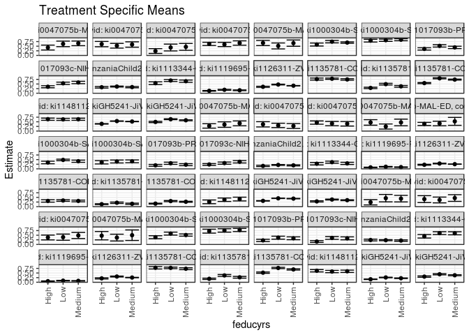

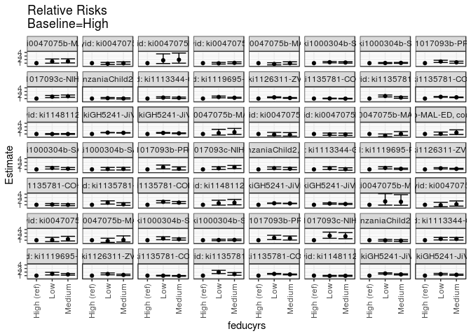

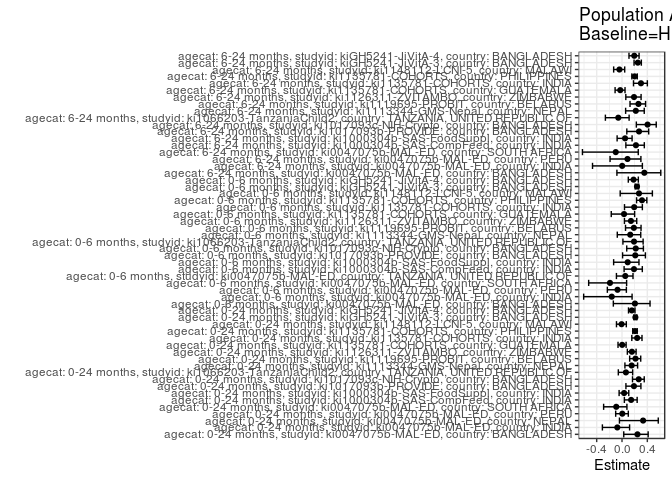

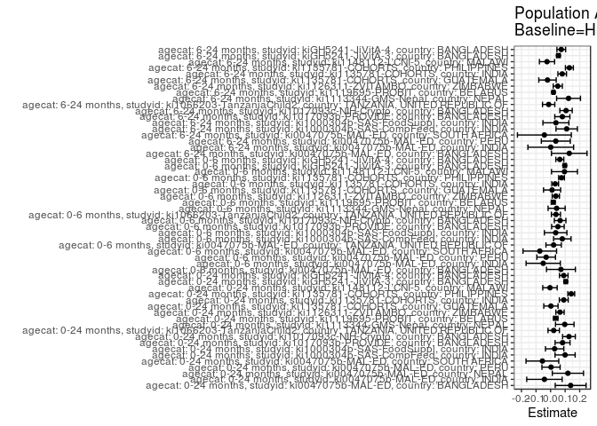

## Results Table

### Parameter: TSM

| agecat | studyid | country | intervention_level | baseline_level | estimate | ci_lower | ci_upper |
| --- | --- | --- | --- | --- | --- | --- | --- |
| 0-24 months | ki0047075b-MAL-ED | BANGLADESH | High | NA | 0.4259259 | 0.2935940 | 0.5582578 |
| 0-24 months | ki0047075b-MAL-ED | BANGLADESH | Low | NA | 0.6250000 | 0.4744655 | 0.7755345 |
| 0-24 months | ki0047075b-MAL-ED | BANGLADESH | Medium | NA | 0.6545455 | 0.5284515 | 0.7806394 |
| 0-24 months | ki0047075b-MAL-ED | INDIA | High | NA | 0.6136364 | 0.4692728 | 0.7579999 |
| 0-24 months | ki0047075b-MAL-ED | INDIA | Low | NA | 0.5254237 | 0.3975704 | 0.6532771 |
| 0-24 months | ki0047075b-MAL-ED | INDIA | Medium | NA | 0.5909091 | 0.4451370 | 0.7366811 |
| 0-24 months | ki0047075b-MAL-ED | NEPAL | High | NA | 0.2380952 | 0.1086231 | 0.3675674 |
| 0-24 months | ki0047075b-MAL-ED | NEPAL | Low | NA | 0.4285714 | 0.2443293 | 0.6128135 |
| 0-24 months | ki0047075b-MAL-ED | NEPAL | Medium | NA | 0.4642857 | 0.2786098 | 0.6499616 |
| 0-24 months | ki0047075b-MAL-ED | PERU | High | NA | 0.6250000 | 0.5382073 | 0.7117927 |
| 0-24 months | ki0047075b-MAL-ED | PERU | Low | NA | 0.5942029 | 0.4781073 | 0.7102985 |
| 0-24 months | ki0047075b-MAL-ED | PERU | Medium | NA | 0.6721311 | 0.5540908 | 0.7901715 |
| 0-24 months | ki0047075b-MAL-ED | SOUTH AFRICA | High | NA | 0.6744186 | 0.5337194 | 0.8151178 |
| 0-24 months | ki0047075b-MAL-ED | SOUTH AFRICA | Low | NA | 0.5135135 | 0.3517272 | 0.6752998 |
| 0-24 months | ki0047075b-MAL-ED | SOUTH AFRICA | Medium | NA | 0.6666667 | 0.4972078 | 0.8361255 |
| 0-24 months | ki1000304b-SAS-CompFeed | INDIA | High | NA | 0.5912596 | 0.5098374 | 0.6726819 |
| 0-24 months | ki1000304b-SAS-CompFeed | INDIA | Low | NA | 0.7461774 | 0.6806454 | 0.8117094 |
| 0-24 months | ki1000304b-SAS-CompFeed | INDIA | Medium | NA | 0.6960986 | 0.6579970 | 0.7342001 |
| 0-24 months | ki1000304b-SAS-FoodSuppl | INDIA | High | NA | 0.8000000 | 0.7251603 | 0.8748397 |
| 0-24 months | ki1000304b-SAS-FoodSuppl | INDIA | Low | NA | 0.8231293 | 0.7613743 | 0.8848842 |
| 0-24 months | ki1000304b-SAS-FoodSuppl | INDIA | Medium | NA | 0.8509317 | 0.7958515 | 0.9060118 |
| 0-24 months | ki1017093b-PROVIDE | BANGLADESH | High | NA | 0.3534483 | 0.2918910 | 0.4150055 |
| 0-24 months | ki1017093b-PROVIDE | BANGLADESH | Low | NA | 0.5168067 | 0.4532744 | 0.5803390 |
| 0-24 months | ki1017093b-PROVIDE | BANGLADESH | Medium | NA | 0.4347826 | 0.3706707 | 0.4988945 |
| 0-24 months | ki1017093c-NIH-Crypto | BANGLADESH | High | NA | 0.3513514 | 0.2969306 | 0.4057721 |
| 0-24 months | ki1017093c-NIH-Crypto | BANGLADESH | Low | NA | 0.5371901 | 0.4743275 | 0.6000527 |
| 0-24 months | ki1017093c-NIH-Crypto | BANGLADESH | Medium | NA | 0.5818182 | 0.5165954 | 0.6470410 |
| 0-24 months | ki1066203-TanzaniaChild2 | TANZANIA, UNITED REPUBLIC OF | High | NA | 0.3251670 | 0.2818292 | 0.3685049 |
| 0-24 months | ki1066203-TanzaniaChild2 | TANZANIA, UNITED REPUBLIC OF | Low | NA | 0.3614173 | 0.3349902 | 0.3878445 |
| 0-24 months | ki1066203-TanzaniaChild2 | TANZANIA, UNITED REPUBLIC OF | Medium | NA | 0.3328313 | 0.2969817 | 0.3686810 |

[output cut: 138 more lines]

### Parameter: E(Y)

| agecat | studyid | country | intervention_level | baseline_level | estimate | ci_lower | ci_upper |
| --- | --- | --- | --- | --- | --- | --- | --- |
| 0-24 months | ki0047075b-MAL-ED | BANGLADESH | NA | NA | 0.5637584 | 0.4838620 | 0.6436548 |
| 0-24 months | ki0047075b-MAL-ED | INDIA | NA | NA | 0.5714286 | 0.4911565 | 0.6517006 |
| 0-24 months | ki0047075b-MAL-ED | NEPAL | NA | NA | 0.3571429 | 0.2617885 | 0.4524972 |
| 0-24 months | ki0047075b-MAL-ED | PERU | NA | NA | 0.6280000 | 0.5679657 | 0.6880343 |
| 0-24 months | ki0047075b-MAL-ED | SOUTH AFRICA | NA | NA | 0.6181818 | 0.5269763 | 0.7093874 |
| 0-24 months | ki1000304b-SAS-CompFeed | INDIA | NA | NA | 0.6908497 | 0.6505448 | 0.7311545 |
| 0-24 months | ki1000304b-SAS-FoodSuppl | INDIA | NA | NA | 0.8277512 | 0.7915095 | 0.8639929 |
| 0-24 months | ki1017093b-PROVIDE | BANGLADESH | NA | NA | 0.4357143 | 0.3989556 | 0.4724730 |
| 0-24 months | ki1017093c-NIH-Crypto | BANGLADESH | NA | NA | 0.4775726 | 0.4419904 | 0.5131548 |
| 0-24 months | ki1066203-TanzaniaChild2 | TANZANIA, UNITED REPUBLIC OF | NA | NA | 0.3466219 | 0.3275107 | 0.3657331 |
| 0-24 months | ki1113344-GMS-Nepal | NEPAL | NA | NA | 0.6408046 | 0.6051362 | 0.6764730 |
| 0-24 months | ki1119695-PROBIT | BELARUS | NA | NA | 0.1652568 | 0.1463320 | 0.1841817 |
| 0-24 months | ki1126311-ZVITAMBO | ZIMBABWE | NA | NA | 0.4136118 | 0.4053631 | 0.4218605 |
| 0-24 months | ki1135781-COHORTS | GUATEMALA | NA | NA | 0.7672000 | 0.7437624 | 0.7906376 |
| 0-24 months | ki1135781-COHORTS | INDIA | NA | NA | 0.3780235 | 0.3530310 | 0.4030160 |
| 0-24 months | ki1135781-COHORTS | PHILIPPINES | NA | NA | 0.6899306 | 0.6730355 | 0.7068256 |
| 0-24 months | ki1148112-LCNI-5 | MALAWI | NA | NA | 0.6371464 | 0.6040748 | 0.6702180 |
| 0-24 months | kiGH5241-JiVitA-3 | BANGLADESH | NA | NA | 0.4931575 | 0.4852626 | 0.5010523 |
| 0-24 months | kiGH5241-JiVitA-4 | BANGLADESH | NA | NA | 0.5820697 | 0.5655159 | 0.5986236 |
| 0-6 months | ki0047075b-MAL-ED | BANGLADESH | NA | NA | 0.3489933 | 0.2722008 | 0.4257857 |
| 0-6 months | ki0047075b-MAL-ED | INDIA | NA | NA | 0.3129252 | 0.2377120 | 0.3881383 |
| 0-6 months | ki0047075b-MAL-ED | PERU | NA | NA | 0.4280000 | 0.3665434 | 0.4894566 |
| 0-6 months | ki0047075b-MAL-ED | SOUTH AFRICA | NA | NA | 0.3909091 | 0.2993052 | 0.4825130 |
| 0-6 months | ki0047075b-MAL-ED | TANZANIA, UNITED REPUBLIC OF | NA | NA | 0.4056604 | 0.3394074 | 0.4719134 |
| 0-6 months | ki1000304b-SAS-CompFeed | INDIA | NA | NA | 0.4250164 | 0.3969651 | 0.4530677 |
| 0-6 months | ki1000304b-SAS-FoodSuppl | INDIA | NA | NA | 0.3894231 | 0.3425088 | 0.4363374 |
| 0-6 months | ki1017093b-PROVIDE | BANGLADESH | NA | NA | 0.2400000 | 0.2083392 | 0.2716608 |
| 0-6 months | ki1017093c-NIH-Crypto | BANGLADESH | NA | NA | 0.3021108 | 0.2694011 | 0.3348205 |
| 0-6 months | ki1066203-TanzaniaChild2 | TANZANIA, UNITED REPUBLIC OF | NA | NA | 0.1951322 | 0.1792173 | 0.2110471 |
| 0-6 months | ki1113344-GMS-Nepal | NEPAL | NA | NA | 0.3189655 | 0.2843148 | 0.3536162 |
| 0-6 months | ki1119695-PROBIT | BELARUS | NA | NA | 0.0977315 | 0.0847284 | 0.1107345 |
| 0-6 months | ki1126311-ZVITAMBO | ZIMBABWE | NA | NA | 0.2565977 | 0.2492783 | 0.2639171 |
| 0-6 months | ki1135781-COHORTS | GUATEMALA | NA | NA | 0.3196078 | 0.2909760 | 0.3482397 |
| 0-6 months | ki1135781-COHORTS | INDIA | NA | NA | 0.1639690 | 0.1447117 | 0.1832264 |
| 0-6 months | ki1135781-COHORTS | PHILIPPINES | NA | NA | 0.2381944 | 0.2226342 | 0.2537546 |
| 0-6 months | ki1148112-LCNI-5 | MALAWI | NA | NA | 0.3558052 | 0.2982716 | 0.4133389 |
| 0-6 months | kiGH5241-JiVitA-3 | BANGLADESH | NA | NA | 0.4111421 | 0.4035964 | 0.4186878 |
| 0-6 months | kiGH5241-JiVitA-4 | BANGLADESH | NA | NA | 0.3469880 | 0.3313196 | 0.3626563 |
| 6-24 months | ki0047075b-MAL-ED | BANGLADESH | NA | NA | 0.3636364 | 0.2625541 | 0.4647186 |
| 6-24 months | ki0047075b-MAL-ED | INDIA | NA | NA | 0.4086022 | 0.3081534 | 0.5090509 |
| 6-24 months | ki0047075b-MAL-ED | PERU | NA | NA | 0.4132231 | 0.3251210 | 0.5013252 |
| 6-24 months | ki0047075b-MAL-ED | SOUTH AFRICA | NA | NA | 0.4310345 | 0.3024734 | 0.5595956 |
| 6-24 months | ki1000304b-SAS-CompFeed | INDIA | NA | NA | 0.5024631 | 0.4586872 | 0.5462389 |
| 6-24 months | ki1000304b-SAS-FoodSuppl | INDIA | NA | NA | 0.7572016 | 0.7031798 | 0.8112234 |
| 6-24 months | ki1017093b-PROVIDE | BANGLADESH | NA | NA | 0.3004386 | 0.2583143 | 0.3425629 |
| 6-24 months | ki1017093c-NIH-Crypto | BANGLADESH | NA | NA | 0.2628458 | 0.2244546 | 0.3012371 |
| 6-24 months | ki1066203-TanzaniaChild2 | TANZANIA, UNITED REPUBLIC OF | NA | NA | 0.2263323 | 0.2057897 | 0.2468748 |
| 6-24 months | ki1113344-GMS-Nepal | NEPAL | NA | NA | 0.5656566 | 0.5167753 | 0.6145378 |
| 6-24 months | ki1119695-PROBIT | BELARUS | NA | NA | 0.0761786 | 0.0621943 | 0.0901630 |
| 6-24 months | ki1126311-ZVITAMBO | ZIMBABWE | NA | NA | 0.2601449 | 0.2506947 | 0.2695951 |
| 6-24 months | ki1135781-COHORTS | GUATEMALA | NA | NA | 0.7617329 | 0.7327499 | 0.7907158 |
| 6-24 months | ki1135781-COHORTS | INDIA | NA | NA | 0.2663274 | 0.2410848 | 0.2915700 |
| 6-24 months | ki1135781-COHORTS | PHILIPPINES | NA | NA | 0.6482312 | 0.6273346 | 0.6691278 |
| 6-24 months | ki1148112-LCNI-5 | MALAWI | NA | NA | 0.5983027 | 0.5621404 | 0.6344650 |
| 6-24 months | kiGH5241-JiVitA-3 | BANGLADESH | NA | NA | 0.2152036 | 0.2057612 | 0.2246461 |
| 6-24 months | kiGH5241-JiVitA-4 | BANGLADESH | NA | NA | 0.3789503 | 0.3597979 | 0.3981028 |

### Parameter: RR

| agecat | studyid | country | intervention_level | baseline_level | estimate | ci_lower | ci_upper |
| --- | --- | --- | --- | --- | --- | --- | --- |
| 0-24 months | ki0047075b-MAL-ED | BANGLADESH | High | High | 1.0000000 | 1.0000000 | 1.000000 |
| 0-24 months | ki0047075b-MAL-ED | BANGLADESH | Low | High | 1.4673913 | 0.9904155 | 2.174075 |
| 0-24 months | ki0047075b-MAL-ED | BANGLADESH | Medium | High | 1.5367589 | 1.0662053 | 2.214984 |
| 0-24 months | ki0047075b-MAL-ED | INDIA | High | High | 1.0000000 | 1.0000000 | 1.000000 |
| 0-24 months | ki0047075b-MAL-ED | INDIA | Low | High | 0.8562461 | 0.6103871 | 1.201135 |
| 0-24 months | ki0047075b-MAL-ED | INDIA | Medium | High | 0.9629630 | 0.6848013 | 1.354112 |
| 0-24 months | ki0047075b-MAL-ED | NEPAL | High | High | 1.0000000 | 1.0000000 | 1.000000 |
| 0-24 months | ki0047075b-MAL-ED | NEPAL | Low | High | 1.8000000 | 0.8999615 | 3.600154 |
| 0-24 months | ki0047075b-MAL-ED | NEPAL | Medium | High | 1.9500000 | 0.9928486 | 3.829889 |
| 0-24 months | ki0047075b-MAL-ED | PERU | High | High | 1.0000000 | 1.0000000 | 1.000000 |
| 0-24 months | ki0047075b-MAL-ED | PERU | Low | High | 0.9507246 | 0.7480880 | 1.208250 |
| 0-24 months | ki0047075b-MAL-ED | PERU | Medium | High | 1.0754098 | 0.8596850 | 1.345268 |
| 0-24 months | ki0047075b-MAL-ED | SOUTH AFRICA | High | High | 1.0000000 | 1.0000000 | 1.000000 |
| 0-24 months | ki0047075b-MAL-ED | SOUTH AFRICA | Low | High | 0.7614166 | 0.5218144 | 1.111037 |
| 0-24 months | ki0047075b-MAL-ED | SOUTH AFRICA | Medium | High | 0.9885057 | 0.7114857 | 1.373385 |
| 0-24 months | ki1000304b-SAS-CompFeed | INDIA | High | High | 1.0000000 | 1.0000000 | 1.000000 |
| 0-24 months | ki1000304b-SAS-CompFeed | INDIA | Low | High | 1.2620130 | 1.0872837 | 1.464822 |
| 0-24 months | ki1000304b-SAS-CompFeed | INDIA | Medium | High | 1.1773145 | 1.0024416 | 1.382694 |
| 0-24 months | ki1000304b-SAS-FoodSuppl | INDIA | High | High | 1.0000000 | 1.0000000 | 1.000000 |
| 0-24 months | ki1000304b-SAS-FoodSuppl | INDIA | Low | High | 1.0289116 | 0.9126380 | 1.159999 |
| 0-24 months | ki1000304b-SAS-FoodSuppl | INDIA | Medium | High | 1.0636646 | 0.9492907 | 1.191819 |
| 0-24 months | ki1017093b-PROVIDE | BANGLADESH | High | High | 1.0000000 | 1.0000000 | 1.000000 |
| 0-24 months | ki1017093b-PROVIDE | BANGLADESH | Low | High | 1.4621849 | 1.1814636 | 1.809607 |
| 0-24 months | ki1017093b-PROVIDE | BANGLADESH | Medium | High | 1.2301166 | 0.9791282 | 1.545443 |
| 0-24 months | ki1017093c-NIH-Crypto | BANGLADESH | High | High | 1.0000000 | 1.0000000 | 1.000000 |
| 0-24 months | ki1017093c-NIH-Crypto | BANGLADESH | Low | High | 1.5289256 | 1.2591533 | 1.856496 |
| 0-24 months | ki1017093c-NIH-Crypto | BANGLADESH | Medium | High | 1.6559441 | 1.3677550 | 2.004855 |
| 0-24 months | ki1066203-TanzaniaChild2 | TANZANIA, UNITED REPUBLIC OF | High | High | 1.0000000 | 1.0000000 | 1.000000 |
| 0-24 months | ki1066203-TanzaniaChild2 | TANZANIA, UNITED REPUBLIC OF | Low | High | 1.1114820 | 0.9547315 | 1.293968 |
| 0-24 months | ki1066203-TanzaniaChild2 | TANZANIA, UNITED REPUBLIC OF | Medium | High | 1.0235703 | 0.8623749 | 1.214896 |

[output cut: 138 more lines]

### Parameter: PAR

| agecat | studyid | country | intervention_level | baseline_level | estimate | ci_lower | ci_upper |
| --- | --- | --- | --- | --- | --- | --- | --- |
| 0-24 months | ki0047075b-MAL-ED | BANGLADESH | High | NA | 0.1378325 | 0.0319925 | 0.2436724 |
| 0-24 months | ki0047075b-MAL-ED | INDIA | High | NA | -0.0422078 | -0.1638971 | 0.0794815 |
| 0-24 months | ki0047075b-MAL-ED | NEPAL | High | NA | 0.1190476 | 0.0118694 | 0.2262258 |
| 0-24 months | ki0047075b-MAL-ED | PERU | High | NA | 0.0030000 | -0.0594935 | 0.0654935 |
| 0-24 months | ki0047075b-MAL-ED | SOUTH AFRICA | High | NA | -0.0562368 | -0.1686540 | 0.0561804 |
| 0-24 months | ki1000304b-SAS-CompFeed | INDIA | High | NA | 0.0995900 | 0.0304356 | 0.1687445 |
| 0-24 months | ki1000304b-SAS-FoodSuppl | INDIA | High | NA | 0.0277512 | -0.0352294 | 0.0907318 |
| 0-24 months | ki1017093b-PROVIDE | BANGLADESH | High | NA | 0.0822660 | 0.0309948 | 0.1335372 |
| 0-24 months | ki1017093c-NIH-Crypto | BANGLADESH | High | NA | 0.1262212 | 0.0824642 | 0.1699783 |
| 0-24 months | ki1066203-TanzaniaChild2 | TANZANIA, UNITED REPUBLIC OF | High | NA | 0.0214549 | -0.0177324 | 0.0606422 |
| 0-24 months | ki1113344-GMS-Nepal | NEPAL | High | NA | 0.0974520 | 0.0338375 | 0.1610665 |
| 0-24 months | ki1119695-PROBIT | BELARUS | High | NA | 0.0352236 | 0.0197299 | 0.0507173 |
| 0-24 months | ki1126311-ZVITAMBO | ZIMBABWE | High | NA | 0.0646118 | 0.0360916 | 0.0931320 |
| 0-24 months | ki1135781-COHORTS | GUATEMALA | High | NA | 0.0022427 | -0.0467200 | 0.0512055 |
| 0-24 months | ki1135781-COHORTS | INDIA | High | NA | 0.0905455 | 0.0601314 | 0.1209597 |
| 0-24 months | ki1135781-COHORTS | PHILIPPINES | High | NA | 0.1419189 | 0.1185167 | 0.1653211 |
| 0-24 months | ki1148112-LCNI-5 | MALAWI | High | NA | -0.0042879 | -0.0537036 | 0.0451278 |
| 0-24 months | kiGH5241-JiVitA-3 | BANGLADESH | High | NA | 0.1043198 | 0.0927520 | 0.1158877 |
| 0-24 months | kiGH5241-JiVitA-4 | BANGLADESH | High | NA | 0.0904900 | 0.0611798 | 0.1198002 |
| 0-6 months | ki0047075b-MAL-ED | BANGLADESH | High | NA | 0.0712155 | -0.0280351 | 0.1704661 |
| 0-6 months | ki0047075b-MAL-ED | INDIA | High | NA | -0.0507112 | -0.1682750 | 0.0668526 |
| 0-6 months | ki0047075b-MAL-ED | PERU | High | NA | -0.0303333 | -0.0943340 | 0.0336673 |
| 0-6 months | ki0047075b-MAL-ED | SOUTH AFRICA | High | NA | -0.0742072 | -0.1894674 | 0.0410531 |
| 0-6 months | ki0047075b-MAL-ED | TANZANIA, UNITED REPUBLIC OF | High | NA | 0.0210450 | -0.0318550 | 0.0739449 |
| 0-6 months | ki1000304b-SAS-CompFeed | INDIA | High | NA | 0.0805434 | 0.0205873 | 0.1404994 |
| 0-6 months | ki1000304b-SAS-FoodSuppl | INDIA | High | NA | 0.0348776 | -0.0424228 | 0.1121781 |
| 0-6 months | ki1017093b-PROVIDE | BANGLADESH | High | NA | 0.0503448 | 0.0071989 | 0.0934908 |
| 0-6 months | ki1017093c-NIH-Crypto | BANGLADESH | High | NA | 0.0656243 | 0.0258276 | 0.1054210 |
| 0-6 months | ki1066203-TanzaniaChild2 | TANZANIA, UNITED REPUBLIC OF | High | NA | 0.0370030 | 0.0059653 | 0.0680407 |
| 0-6 months | ki1113344-GMS-Nepal | NEPAL | High | NA | 0.0415089 | -0.0171635 | 0.1001813 |
| 0-6 months | ki1119695-PROBIT | BELARUS | High | NA | 0.0183077 | 0.0051598 | 0.0314557 |
| 0-6 months | ki1126311-ZVITAMBO | ZIMBABWE | High | NA | 0.0361568 | 0.0112859 | 0.0610277 |
| 0-6 months | ki1135781-COHORTS | GUATEMALA | High | NA | 0.0103295 | -0.0483505 | 0.0690094 |
| 0-6 months | ki1135781-COHORTS | INDIA | High | NA | 0.0315898 | 0.0083678 | 0.0548118 |
| 0-6 months | ki1135781-COHORTS | PHILIPPINES | High | NA | 0.0752459 | 0.0555859 | 0.0949058 |
| 0-6 months | ki1148112-LCNI-5 | MALAWI | High | NA | 0.0955313 | 0.0065435 | 0.1845191 |
| 0-6 months | kiGH5241-JiVitA-3 | BANGLADESH | High | NA | 0.0973107 | 0.0860302 | 0.1085911 |
| 0-6 months | kiGH5241-JiVitA-4 | BANGLADESH | High | NA | 0.0633300 | 0.0360982 | 0.0905619 |
| 6-24 months | ki0047075b-MAL-ED | BANGLADESH | High | NA | 0.1283422 | 0.0063135 | 0.2503710 |
| 6-24 months | ki0047075b-MAL-ED | INDIA | High | NA | 0.0011947 | -0.1558118 | 0.1582013 |
| 6-24 months | ki0047075b-MAL-ED | PERU | High | NA | 0.0358646 | -0.0635874 | 0.1353167 |
| 6-24 months | ki0047075b-MAL-ED | SOUTH AFRICA | High | NA | -0.0426497 | -0.2276203 | 0.1423208 |
| 6-24 months | ki1000304b-SAS-CompFeed | INDIA | High | NA | 0.1106263 | 0.0371136 | 0.1841390 |
| 6-24 months | ki1000304b-SAS-FoodSuppl | INDIA | High | NA | 0.0366134 | -0.0525349 | 0.1257617 |
| 6-24 months | ki1017093b-PROVIDE | BANGLADESH | High | NA | 0.0807854 | 0.0288758 | 0.1326950 |
| 6-24 months | ki1017093c-NIH-Crypto | BANGLADESH | High | NA | 0.1061638 | 0.0636505 | 0.1486771 |
| 6-24 months | ki1066203-TanzaniaChild2 | TANZANIA, UNITED REPUBLIC OF | High | NA | -0.0132843 | -0.0554905 | 0.0289219 |
| 6-24 months | ki1113344-GMS-Nepal | NEPAL | High | NA | 0.1233489 | 0.0413372 | 0.2053605 |
| 6-24 months | ki1119695-PROBIT | BELARUS | High | NA | 0.0197768 | 0.0104367 | 0.0291169 |
| 6-24 months | ki1126311-ZVITAMBO | ZIMBABWE | High | NA | 0.0493606 | 0.0180678 | 0.0806535 |
| 6-24 months | ki1135781-COHORTS | GUATEMALA | High | NA | -0.0211619 | -0.0808902 | 0.0385664 |
| 6-24 months | ki1135781-COHORTS | INDIA | High | NA | 0.0797446 | 0.0502379 | 0.1092513 |
| 6-24 months | ki1135781-COHORTS | PHILIPPINES | High | NA | 0.1292769 | 0.1021706 | 0.1563833 |
| 6-24 months | ki1148112-LCNI-5 | MALAWI | High | NA | -0.0245043 | -0.0766089 | 0.0276002 |
| 6-24 months | kiGH5241-JiVitA-3 | BANGLADESH | High | NA | 0.0537978 | 0.0412026 | 0.0663931 |
| 6-24 months | kiGH5241-JiVitA-4 | BANGLADESH | High | NA | 0.0734558 | 0.0435704 | 0.1033412 |

### Parameter: PAF

| agecat | studyid | country | intervention_level | baseline_level | estimate | ci_lower | ci_upper |
| --- | --- | --- | --- | --- | --- | --- | --- |
| 0-24 months | ki0047075b-MAL-ED | BANGLADESH | High | NA | 0.2444885 | 0.0274820 | 0.4130725 |
| 0-24 months | ki0047075b-MAL-ED | INDIA | High | NA | -0.0738636 | -0.3099772 | 0.1196922 |
| 0-24 months | ki0047075b-MAL-ED | NEPAL | High | NA | 0.3333333 | -0.0403132 | 0.5727782 |
| 0-24 months | ki0047075b-MAL-ED | PERU | High | NA | 0.0047771 | -0.0998828 | 0.0994780 |
| 0-24 months | ki0047075b-MAL-ED | SOUTH AFRICA | High | NA | -0.0909713 | -0.2903350 | 0.0775897 |
| 0-24 months | ki1000304b-SAS-CompFeed | INDIA | High | NA | 0.1441559 | 0.0371937 | 0.2392351 |
| 0-24 months | ki1000304b-SAS-FoodSuppl | INDIA | High | NA | 0.0335260 | -0.0457624 | 0.1068028 |
| 0-24 months | ki1017093b-PROVIDE | BANGLADESH | High | NA | 0.1888072 | 0.0618582 | 0.2985776 |
| 0-24 months | ki1017093c-NIH-Crypto | BANGLADESH | High | NA | 0.2642974 | 0.1658996 | 0.3510874 |
| 0-24 months | ki1066203-TanzaniaChild2 | TANZANIA, UNITED REPUBLIC OF | High | NA | 0.0618970 | -0.0582521 | 0.1684050 |
| 0-24 months | ki1113344-GMS-Nepal | NEPAL | High | NA | 0.1520776 | 0.0459406 | 0.2464070 |
| 0-24 months | ki1119695-PROBIT | BELARUS | High | NA | 0.2131445 | 0.1209727 | 0.2956515 |
| 0-24 months | ki1126311-ZVITAMBO | ZIMBABWE | High | NA | 0.1562136 | 0.0843492 | 0.2224378 |
| 0-24 months | ki1135781-COHORTS | GUATEMALA | High | NA | 0.0029233 | -0.0629839 | 0.0647440 |
| 0-24 months | ki1135781-COHORTS | INDIA | High | NA | 0.2395236 | 0.1547888 | 0.3157635 |
| 0-24 months | ki1135781-COHORTS | PHILIPPINES | High | NA | 0.2057003 | 0.1700694 | 0.2398014 |
| 0-24 months | ki1148112-LCNI-5 | MALAWI | High | NA | -0.0067298 | -0.0873556 | 0.0679176 |
| 0-24 months | kiGH5241-JiVitA-3 | BANGLADESH | High | NA | 0.2115345 | 0.1876288 | 0.2347368 |
| 0-24 months | kiGH5241-JiVitA-4 | BANGLADESH | High | NA | 0.1554624 | 0.1027529 | 0.2050754 |
| 0-6 months | ki0047075b-MAL-ED | BANGLADESH | High | NA | 0.2040598 | -0.1370274 | 0.4428272 |
| 0-6 months | ki0047075b-MAL-ED | INDIA | High | NA | -0.1620553 | -0.6057524 | 0.1590406 |
| 0-6 months | ki0047075b-MAL-ED | PERU | High | NA | -0.0708723 | -0.2315900 | 0.0688724 |
| 0-6 months | ki0047075b-MAL-ED | SOUTH AFRICA | High | NA | -0.1898323 | -0.5266938 | 0.0727014 |
| 0-6 months | ki0047075b-MAL-ED | TANZANIA, UNITED REPUBLIC OF | High | NA | 0.0518784 | -0.0880127 | 0.1737829 |
| 0-6 months | ki1000304b-SAS-CompFeed | INDIA | High | NA | 0.1895065 | 0.0330162 | 0.3206714 |
| 0-6 months | ki1000304b-SAS-FoodSuppl | INDIA | High | NA | 0.0895623 | -0.1322979 | 0.2679516 |
| 0-6 months | ki1017093b-PROVIDE | BANGLADESH | High | NA | 0.2097701 | 0.0092456 | 0.3697093 |
| 0-6 months | ki1017093c-NIH-Crypto | BANGLADESH | High | NA | 0.2172194 | 0.0745602 | 0.3378873 |
| 0-6 months | ki1066203-TanzaniaChild2 | TANZANIA, UNITED REPUBLIC OF | High | NA | 0.1896305 | 0.0144430 | 0.3336775 |
| 0-6 months | ki1113344-GMS-Nepal | NEPAL | High | NA | 0.1301359 | -0.0745812 | 0.2958527 |
| 0-6 months | ki1119695-PROBIT | BELARUS | High | NA | 0.1873270 | 0.0555382 | 0.3007262 |
| 0-6 months | ki1126311-ZVITAMBO | ZIMBABWE | High | NA | 0.1409086 | 0.0383417 | 0.2325361 |
| 0-6 months | ki1135781-COHORTS | GUATEMALA | High | NA | 0.0323193 | -0.1698513 | 0.1995512 |
| 0-6 months | ki1135781-COHORTS | INDIA | High | NA | 0.1926570 | 0.0393285 | 0.3215135 |
| 0-6 months | ki1135781-COHORTS | PHILIPPINES | High | NA | 0.3159009 | 0.2298567 | 0.3923319 |
| 0-6 months | ki1148112-LCNI-5 | MALAWI | High | NA | 0.2684932 | -0.0286647 | 0.4798089 |
| 0-6 months | kiGH5241-JiVitA-3 | BANGLADESH | High | NA | 0.2366838 | 0.2088263 | 0.2635604 |
| 0-6 months | kiGH5241-JiVitA-4 | BANGLADESH | High | NA | 0.1825136 | 0.0993838 | 0.2579703 |
| 6-24 months | ki0047075b-MAL-ED | BANGLADESH | High | NA | 0.3529412 | -0.0805799 | 0.6125367 |
| 6-24 months | ki0047075b-MAL-ED | INDIA | High | NA | 0.0029240 | -0.4658740 | 0.3217967 |
| 6-24 months | ki0047075b-MAL-ED | PERU | High | NA | 0.0867925 | -0.1888409 | 0.2985201 |
| 6-24 months | ki0047075b-MAL-ED | SOUTH AFRICA | High | NA | -0.0989474 | -0.6249220 | 0.2567734 |
| 6-24 months | ki1000304b-SAS-CompFeed | INDIA | High | NA | 0.2201681 | 0.0608768 | 0.3524408 |
| 6-24 months | ki1000304b-SAS-FoodSuppl | INDIA | High | NA | 0.0483536 | -0.0772550 | 0.1593161 |
| 6-24 months | ki1017093b-PROVIDE | BANGLADESH | High | NA | 0.2688916 | 0.0759330 | 0.4215577 |
| 6-24 months | ki1017093c-NIH-Crypto | BANGLADESH | High | NA | 0.4039015 | 0.2263199 | 0.5407230 |
| 6-24 months | ki1066203-TanzaniaChild2 | TANZANIA, UNITED REPUBLIC OF | High | NA | -0.0586939 | -0.2625698 | 0.1122608 |
| 6-24 months | ki1113344-GMS-Nepal | NEPAL | High | NA | 0.2180632 | 0.0572434 | 0.3514496 |
| 6-24 months | ki1119695-PROBIT | BELARUS | High | NA | 0.2596111 | 0.1265182 | 0.3724245 |
| 6-24 months | ki1126311-ZVITAMBO | ZIMBABWE | High | NA | 0.1897427 | 0.0601634 | 0.3014565 |
| 6-24 months | ki1135781-COHORTS | GUATEMALA | High | NA | -0.0277812 | -0.1093038 | 0.0477502 |
| 6-24 months | ki1135781-COHORTS | INDIA | High | NA | 0.2994231 | 0.1814976 | 0.4003586 |
| 6-24 months | ki1135781-COHORTS | PHILIPPINES | High | NA | 0.1994303 | 0.1554983 | 0.2410769 |
| 6-24 months | ki1148112-LCNI-5 | MALAWI | High | NA | -0.0409564 | -0.1318706 | 0.0426554 |
| 6-24 months | kiGH5241-JiVitA-3 | BANGLADESH | High | NA | 0.2499858 | 0.1900997 | 0.3054437 |
| 6-24 months | kiGH5241-JiVitA-4 | BANGLADESH | High | NA | 0.1938403 | 0.1102473 | 0.2695796 |